# Bipolar Disorder Risk Group Clustering k Calculation: fallback_emo_ace (report)

Sam A. Sievertsen

2026-09-29

## Data Prep for k Value Analysis

Prepare the risk variable data for clustering the **fallback_emo_ace** configuration (22 features) by:

1. Selecting this configuration’s features, as defined in `cluster_configs.R`
2. Converting categorical variables to factors for proper handling
3. Preserving participant IDs as row names for later identification
4. Applying the specified scaling method (i.e., z scaling) to continuous variables while leaving categorical variables unchanged

```r
## Data Prep ##

#1. Retrieve this configuration's features and verify they are all present
feats <- cluster_configs[[config]]
missing_feats <- setdiff(feats, names(risk_variable_data))
if (length(missing_feats) > 0) stop("risk_variable_data.csv is missing: ", paste(missing_feats, collapse = ", "))

#2. Ensure dichotimization of categorical data for clustering
risk_variable_data <- risk_variable_data %>%
  mutate(across(any_of(feats_categorical), as.factor))

#3. Retain subject IDs as row names while keeping only this configuration's features
#3.1 Select the configuration's features, in the order defined in cluster_configs.R
risk_variable_clustering_data <- risk_variable_data[, feats, drop = FALSE]

#3.2 Set subject IDs as row names
row.names(risk_variable_clustering_data) <- risk_variable_data$participant_id

#3.3 Confirm the data are complete, which the wrangling script guarantees for the union of all configurations
stopifnot(!anyNA(risk_variable_clustering_data))

#4. Identify continuous and categorical variables
continuous_vars <- names(risk_variable_clustering_data)[sapply(risk_variable_clustering_data, is.numeric)]
categorical_vars <- names(risk_variable_clustering_data)[sapply(risk_variable_clustering_data, is.factor)]
stopifnot(length(continuous_vars) + length(categorical_vars) == length(feats))

#5. Scaling function to be matched with established param
apply_scaling <- function(df, method) {
  out <- df
  if (method != "none") {
    cont <- df[continuous_vars]
    scaled <- switch(method,
      z_score = scale(cont),
      min_max = purrr::map_df(cont, ~ (.x - min(.x, na.rm=TRUE)) / (max(.x, na.rm=TRUE) - min(.x, na.rm=TRUE))),
      percentile = purrr::map_df(cont, ~ rank(.x, na.last="keep") / sum(!is.na(.x)) * 100),
      max_absolute = purrr::map_df(cont, ~ .x / max(abs(.x), na.rm=TRUE)),
      robust = purrr::map_df(cont, ~ (.x - median(.x, na.rm=TRUE)) / (IQR(.x, na.rm=TRUE) %||% 1))
    )
    out[continuous_vars] <- scaled
  }
  out
}

#6. Scale data according to param set in script call
scaled_data <- apply_scaling(risk_variable_clustering_data, scaling_method)

#7. Build a fingerprint of this exact feature set and participant set, used to validate any cached kproto fits
fingerprint <- list(
  config = config,
  scaling_method = scaling_method,
  features = names(scaled_data),
  participant_id = rownames(scaled_data)
)

#8. Report the configuration composition
tibble(
  Config = config,
  `N participants` = nrow(scaled_data),
  `N features` = ncol(scaled_data),
  `N continuous` = length(continuous_vars),
  `N categorical` = length(categorical_vars)
) %>%
  kable(caption = "Clustering configuration") %>%
  kable_styling(bootstrap_options = c("striped", "hover", "condensed", "responsive"))
```

Clustering configuration

| Config | N participants | N features | N continuous | N categorical |
| --- | --- | --- | --- | --- |
| fallback_emo_ace | 9040 | 22 | 15 | 7 |

## Fit k-Prototypes Solutions

In **fit** mode, k-prototypes solutions for *k* = 2:8 are fit once (`nstart` = 8, package-default data-driven lambda) and cached with an embedded fingerprint. Individual silhouette widths are then computed per *k* in a separate SLURM array using `kproto2silhouette()` (clustMixType 0.5-2) on these cached fits, so no solution is ever refit for validation.

```r
## Fit and cache k-prototypes solutions ##

#1. Load a valid cache if one exists; otherwise fit
#1.1 A cache is only reused if its fingerprint matches this exact feature set and participant set
cache_valid <- FALSE
if (file.exists(proto_file) && isFALSE(params$overwrite)) {
  cached <- readRDS(proto_file)
  cache_valid <- identical(attr(cached, "fingerprint"), fingerprint)
  if (!cache_valid) {
    stop("Cached ", basename(proto_file), " does not match the current features/participants. ",
         "Rerun with overwrite = TRUE if the data have intentionally changed.")
  }
  kp_list <- cached
  log_event("PROTO_SKIP", config, scaling_method, glue("loaded {length(kp_list)} ks from validated cache"))
}

#1.2 Fit in parallel across k, respecting the SLURM/cgroup allocation
if (!cache_valid) {

  #1.2.1 Configure workers
  n_workers <- min(as.integer(parallelly::availableCores()), length(k_vals))
  if (n_workers > 1) plan(multicore, workers = n_workers) else plan(sequential)

  #1.2.2 Start the kproto timer
  proto_start <- Sys.time()
  log_event("PROTO_START", config, scaling_method, glue("workers={n_workers}"))

  #1.2.3 Execute kproto across k, keeping the data so silhouette widths can be computed from the cached objects
  kp_list <- future_map(
    k_vals,
    ~ kproto(x = scaled_data,
             k = .x,
             nstart = params$nstart,
             keep.data = TRUE,
             verbose = FALSE),
    .options = furrr_options(seed = TRUE)
  )
  names(kp_list) <- paste0("k", k_vals)

  #1.2.4 Embed the fingerprint and save
  attr(kp_list, "fingerprint") <- fingerprint
  saveRDS(kp_list, proto_file)

  #1.2.5 End the kproto timer & log
  proto_end <- Sys.time()
  proto_min <- as.numeric(difftime(proto_end, proto_start, units = "mins"))
  log_event("PROTO_END", config, scaling_method, glue("duration={round(proto_min, 1)}min"))
  cat(sprintf("%s,fit,done,%s,%s,%.1f\n", config, format(proto_start, "%Y-%m-%d %H:%M:%OS3"),
              format(proto_end, "%Y-%m-%d %H:%M:%OS3"), proto_min), file = summary_csv, append = TRUE)
  plan(sequential)
}

#2. Summarize the fitted solutions
purrr::imap_dfr(kp_list, ~ tibble(
  k = length(.x$size),
  lambda = mean(.x$lambda),
  `Cluster sizes` = paste(sort(.x$size, decreasing = TRUE), collapse = " / "),
  `Min cluster n` = min(.x$size),
  WSS = .x$tot.withinss,
  Iterations = .x$iter
)) %>%
  kable(caption = glue("Fitted k-prototypes solutions ({config}, {scaling_method})"), digits = 3) %>%
  kable_styling(bootstrap_options = c("striped", "hover", "condensed", "responsive"))
```

## Report: Determining the Optimal Number of Clusters (*k*)

In **report** mode, this section reads the cached fits and the merged silhouette object, then combines descriptive elbow analysis with the silhouette index to arrive at a transparent recommendation for *k* between 2 and 8:

1. **Elbow method** The within cluster sum of squares (WSS) across *k*, with the Kneedle algorithm [Satopaa *et al.*, 2011] via the `inflection` package (Emekes, 2017) to quantitatively identify the elbow point. Descriptive rather than prescriptive
2. **Silhouette index** Individual silhouette widths from `kproto2silhouette()` for every participant at every *k*, averaged to the mean silhouette. Each *k* is independently verified against an exact closed-form computation of the same quantity
3. **Compactness and separation** RMSSD and mixed-type R² across *k*, and UMAP embeddings for the leading candidate solutions

```r
## Determining Optimal Number of Clusters (k Value) ##

#1. Load the validated kproto cache and the merged silhouette object
#1.1 Load and validate the kproto cache
if (!file.exists(proto_file)) stop("No kproto cache for ", config, ". Run mode = 'fit' first.")
kp_list <- readRDS(proto_file)
if (!identical(attr(kp_list, "fingerprint"), fingerprint)) {
  stop("Cached ", basename(proto_file), " does not match the current features/participants.")
}

#1.2 Load the merged silhouette object written by 2_4_merge_silhouette.sh
if (!file.exists(validation_file)) stop("No merged silhouette object for ", config, ". Run the silhouette array and merge first.")
vr_sil <- readRDS(validation_file)

#1.3 Report the estimator provenance and verification for every k
vr_sil$provenance %>%
  kable(caption = "Silhouette provenance and verification per k (max_abs_diff compares kproto2silhouette to the exact closed form)",
        digits = 20) %>%
  kable_styling(bootstrap_options = c("striped", "hover", "condensed", "responsive"))
```

Silhouette provenance and verification per k (max_abs_diff compares kproto2silhouette to the exact closed form)

| k | source | mean_silhouette | max_abs_diff_vs_exact | n_neighbor_mismatch | seconds |
| --- | --- | --- | --- | --- | --- |
| 2 | kproto2silhouette | 0.316941858 | 0.00000000000000047878 | 0 | 676.38027 |
| 3 | kproto2silhouette | 0.160312097 | 0.00000000000000062060 | 0 | 629.06229 |
| 4 | kproto2silhouette | 0.161574412 | 0.00000000000000063057 | 0 | 638.64532 |
| 5 | kproto2silhouette | 0.124699935 | 0.00000000000000065226 | 0 | 691.34065 |
| 6 | kproto2silhouette | 0.114411754 | 0.00000000000000065226 | 0 | 651.90385 |
| 7 | kproto2silhouette | 0.121200425 | 0.00000000000000074246 | 0 | 591.34554 |
| 8 | kproto2silhouette | 0.099656351 | 0.00000000000000077716 | 0 | 612.15862 |

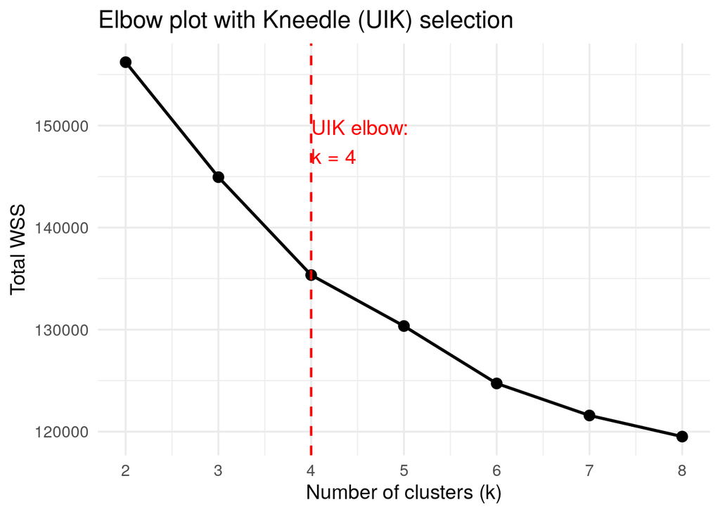

```r
#1.4 Stop if any k fell back to the closed form, so a substitution can never pass unnoticed into the manuscript
if (any(vr_sil$provenance$source != "kproto2silhouette")) {
  warning("One or more k used the exact closed-form fallback rather than kproto2silhouette(); see provenance table.")
}

#1.5 Extract WSS for elbow diagnostics
wss_vec <- map_dbl(kp_list, "tot.withinss")
names(wss_vec) <- k_vals
for (j in seq_along(k_vals)) log_event("WSS", config, scaling_method, glue("k={k_vals[j]}"), glue("wss={round(wss_vec[j], 1)}"))

#2. Generate elbow diagnostics & Kneedle (UIK)
#2.1 Prepare a data.frame for plotting
elbow_df <- tibble(k = as.integer(names(wss_vec)), wss = as.numeric(wss_vec))

#2.2 Find the knee via the Kneedle (UIK) algorithm
knee <- uik(elbow_df$k, elbow_df$wss)
log_event("UIK_ELBOW", config, scaling_method, glue("k={knee}"))

#2.3 Elbow plot with UIK annotation
elbow_plot_uik <- ggplot(elbow_df, aes(x = k, y = wss)) +
  geom_line(linewidth = 1) +
  geom_point(size = 3) +
  geom_vline(xintercept = knee, linetype = "dashed", linewidth = 0.8, color = "red") +
  annotate("text", x = knee, y = max(elbow_df$wss) * 0.95, label = paste0("UIK elbow:\nk = ", knee),
           hjust = 0, size = 5, color = "red") +
  scale_x_continuous(breaks = k_vals) +
  labs(x = "Number of clusters (k)", y = "Total WSS", title = "Elbow plot with Kneedle (UIK) selection") +
  theme_minimal(base_size = 14)
print(elbow_plot_uik)
```

```r
#2.4 Cluster compactness / separation metrics per k
#2.4.1 Compute mixed type total sum of squares (TSS) once via 1-cluster prototype
t1 <- kproto(x = scaled_data, k = 1, nstart = 1, verbose = FALSE)
TSS_mixed <- t1$tot.withinss

#2.4.2 Loop over each k to compute RMSSD & R2
cluster_metrics <- purrr::map_dfr(k_vals, function(k) {
  kp <- kp_list[[paste0("k", k)]]
  rmssd <- sqrt(mean(kp$withinss / as.numeric(kp$size)))
  r2 <- (TSS_mixed - kp$tot.withinss) / TSS_mixed
  log_event("METRICS", config, scaling_method, glue("k={k}"), glue("RMSSD={round(rmssd, 4)}"), glue("R2={round(r2, 4)}"))
  tibble(k = k, RMSSD = rmssd, R2 = r2)
})

#2.4.3 Print a summary table
cluster_metrics %>%
  kable(caption = glue("Compactness/separation metrics per k ({config}, {scaling_method})"), digits = 3) %>%
  kable_styling(bootstrap_options = c("striped", "hover", "condensed", "responsive"))
```

Compactness/separation metrics per k (fallback_emo_ace, z_score)

| k | RMSSD | R2 |
| --- | --- | --- |
| 2 | 4.513 | 0.116 |
| 3 | 4.240 | 0.179 |
| 4 | 4.154 | 0.234 |
| 5 | 4.032 | 0.262 |
| 6 | 3.977 | 0.294 |
| 7 | 3.962 | 0.312 |
| 8 | 3.870 | 0.323 |

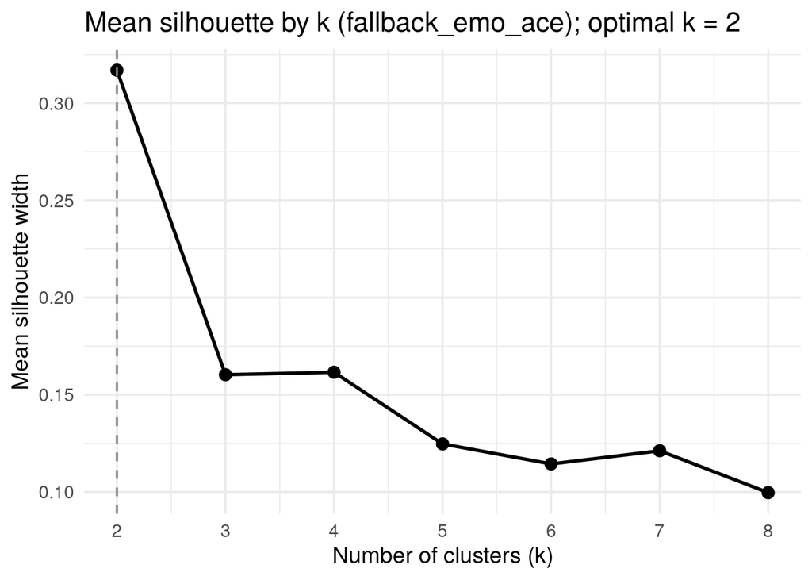

```r
#3. Silhouette index across k
#3.1 Assemble the mean silhouette per k
sil_df <- tibble(k = as.integer(names(vr_sil$indices)), silhouette = as.numeric(vr_sil$indices))
k_opt <- vr_sil$k_opt
log_event("SIL_K_OPT", config, scaling_method, glue("k_opt={k_opt}"), glue("mean_sil={round(vr_sil$index_opt, 4)}"))

#3.2 Plot the silhouette trajectory
sil_plot <- ggplot(sil_df, aes(x = k, y = silhouette)) +
  geom_line(linewidth = 1) +
  geom_point(size = 3) +
  geom_vline(xintercept = k_opt, linetype = "dashed", color = "grey50") +
  scale_x_continuous(breaks = k_vals) +
  labs(x = "Number of clusters (k)", y = "Mean silhouette width",
       title = glue("Mean silhouette by k ({config}); optimal k = {k_opt}")) +
  theme_minimal(base_size = 14)
print(sil_plot)
```

```r
#3.3 Tabulate mean silhouette with the margin over the next-best k
sil_df %>%
  mutate(`Margin vs best` = silhouette - max(silhouette)) %>%
  kable(caption = glue("Mean silhouette by k ({config})"), digits = 4) %>%
  kable_styling(bootstrap_options = c("striped", "hover", "condensed", "responsive"))
```

Mean silhouette by k (fallback_emo_ace)

| k | silhouette | Margin vs best |
| --- | --- | --- |
| 2 | 0.3169 | 0.0000 |
| 3 | 0.1603 | -0.1566 |
| 4 | 0.1616 | -0.1554 |
| 5 | 0.1247 | -0.1922 |
| 6 | 0.1144 | -0.2025 |
| 7 | 0.1212 | -0.1957 |
| 8 | 0.0997 | -0.2173 |

```r
#4. Individual silhouette widths at the optimal k
#4.1 Extract the per-participant object for k_opt
sil_kopt <- vr_sil$individual[[paste0("k", k_opt)]]

#4.2 Summarize widths by cluster, including the share of poorly assigned participants (negative widths)
sil_kopt$table %>%
  group_by(cluster) %>%
  summarise(
    n = n(),
    mean_width = mean(sil_width),
    median_width = median(sil_width),
    pct_negative = 100 * mean(sil_width < 0),
    .groups = "drop") %>%
  kable(caption = glue("Individual silhouette widths by cluster at k = {k_opt} ({config})"), digits = 3) %>%
  kable_styling(bootstrap_options = c("striped", "hover", "condensed", "responsive"))
```

Individual silhouette widths by cluster at k = 2 (fallback_emo_ace)

| cluster | n | mean_width | median_width | pct_negative |
| --- | --- | --- | --- | --- |
| 1 | 6969 | 0.418 | 0.431 | 0.000 |
| 2 | 2071 | -0.022 | -0.043 | 58.764 |

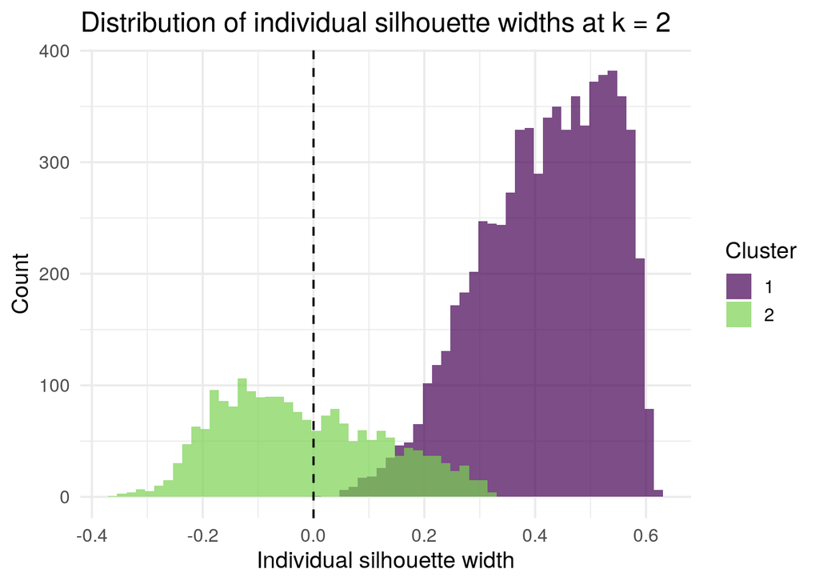

```r
#4.3 Plot the distribution of individual widths by cluster
sil_dist_plot <- ggplot(sil_kopt$table, aes(x = sil_width, fill = factor(cluster))) +
  geom_histogram(bins = 60, alpha = 0.7, position = "identity") +
  geom_vline(xintercept = 0, linetype = "dashed") +
  scale_fill_viridis_d(option = "D", end = 0.8) +
  labs(x = "Individual silhouette width", y = "Count", fill = "Cluster",
       title = glue("Distribution of individual silhouette widths at k = {k_opt}")) +
  theme_minimal(base_size = 14)
print(sil_dist_plot)
```

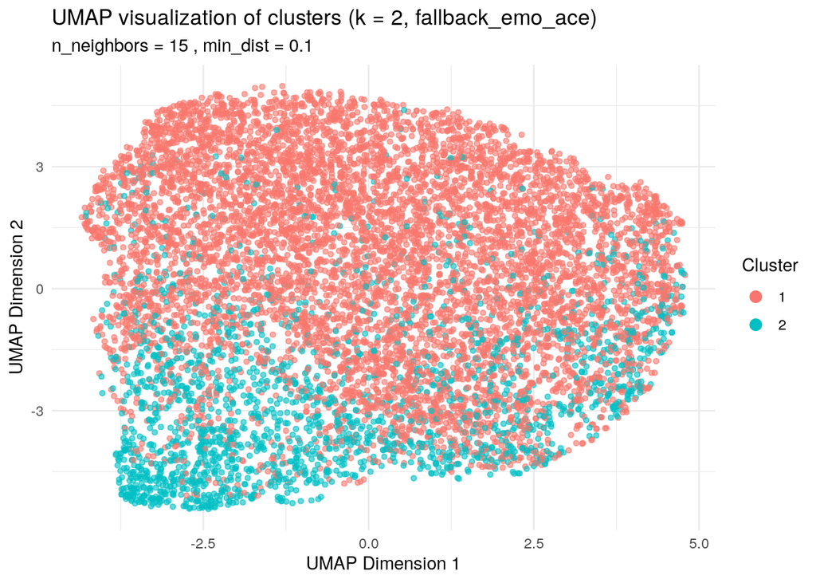

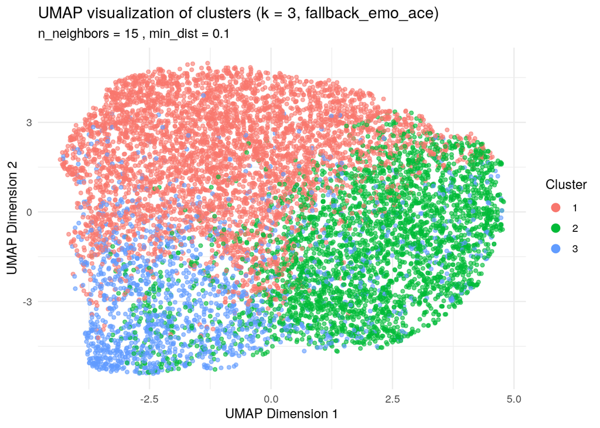

```r
#4.4 Write the per-participant widths for every k to CSV for downstream use
purrr::imap_dfr(vr_sil$individual, ~ mutate(.x$table, k = as.integer(sub("k", "", .y)))) %>%
  dplyr::select(participant_id, k, cluster, neighbor, sil_width) %>%
  write.csv(file.path(validation_dir, sprintf("silhouette_individual_%s_%s.csv", config, scaling_method)), row.names = FALSE)

#5. UMAP & blob diagnostics for the leading candidate solutions
#5.1 One hot encode categorical variables + pipe in scaled numerics
prepare_mixed_data <- function(data) {
  cat_cols <- sapply(data, function(x) is.factor(x) || is.character(x))
  num_cols <- sapply(data, is.numeric)
  comps <- list()
  if (any(cat_cols)) {
    cd <- data[, cat_cols, drop = FALSE]
    cd[] <- lapply(cd, function(x) if (is.character(x)) as.factor(x) else x)
    comps$cat <- dummy_cols(cd, remove_first_dummy = TRUE, remove_selected_columns = TRUE)
  }
  if (any(num_cols)) comps$num <- as.data.frame(data[, num_cols, drop = FALSE])
  do.call(cbind, comps)
}

#5.2 Compute the UMAP embedding once, since it depends only on the data and not on k
umap_config <- umap.defaults
umap_config$n_neighbors <- 15
umap_config$min_dist <- 0.1
umap_config$spread <- 1.5
umap_config$n_epochs <- 500
umap_result <- umap(prepare_mixed_data(scaled_data), config = umap_config)

#5.3 Plot the embedding for the optimal k and its neighbors
for (k in intersect(sort(unique(c(k_opt, 2, 3))), k_vals)) {
  umap_df <- data.frame(
    UMAP1 = umap_result$layout[, 1],
    UMAP2 = umap_result$layout[, 2],
    Cluster = factor(kp_list[[paste0("k", k)]]$cluster))
  p_umap <- ggplot(umap_df, aes(x = UMAP1, y = UMAP2, color = Cluster)) +
    geom_point(size = 1.2, alpha = 0.6) +
    labs(title = glue("UMAP visualization of clusters (k = {k}, {config})"),
         subtitle = paste("n_neighbors =", umap_config$n_neighbors, ", min_dist =", umap_config$min_dist),
         x = "UMAP Dimension 1", y = "UMAP Dimension 2") +
    theme_minimal() +
    guides(color = guide_legend(override.aes = list(alpha = 1, size = 3)))
  print(p_umap)
}
```

```r
#6. Record completion
cat(sprintf("%s,report,done,%s,%s,NA\n", config, format(Sys.time(), "%Y-%m-%d %H:%M:%OS3"),
            format(Sys.time(), "%Y-%m-%d %H:%M:%OS3")), file = summary_csv, append = TRUE)
```

**Interpretation (fallback_emo_ace):**

- Mean silhouette is maximized at *k* = 2 (0.317), exceeding the next-best *k* by 0.155
- The UIK elbow is at *k* = 4, treated as descriptive rather than prescriptive
- Individual silhouette widths were computed with `kproto2silhouette()` and independently verified at every *k* against a closed-form computation (maximum absolute difference across all *k* = 0.000000000000000777)